# CerberusTS Example: Climate Data Forecasting

In this vignette we will demonstrate how CerberusTS for R can be used for multivariate timeseries forecasting.

First let’s load our dependencies.

```r
rm(list=ls())
library(dplyr)
library(abind)
library(keras)
library(tensorflow)

library(cerberusR)
```

First we pull in some sample timeseries, in this case we will use the climate timeseries from https://www.kaggle.com/datasets/mnassrib/jena-climate, saved to the data directory.

```r
time_series_data <- read.csv("../data/jena_climate_2009_2016.csv")
```

I will just pull the first bit of data for the demo.

```r
time_series_data <- time_series_data[1:60000,]
```

Clean up the data:

```r
names(time_series_data)=gsub("[.]","",names(time_series_data))
time_series_data[[1]]=as.POSIXct(time_series_data[[1]],format="%d.%m.%Y %H:%M:%S")
names(time_series_data)[1]="timestamp"

library(knitr)
library(kableExtra)
kable(head(time_series_data), "html") %>% kable_styling("striped") %>% scroll_box(width = "100%")
```

| timestamp | pmbar | TdegC | TpotK | TdewdegC | rh | VPmaxmbar | VPactmbar | VPdefmbar | shgkg | H2OCmmolmol | rhogm3 | wvms | maxwvms | wddeg |
| --- | --- | --- | --- | --- | --- | --- | --- | --- | --- | --- | --- | --- | --- | --- |
| 2009-01-01 00:10:00 | 996.52 | -8.02 | 265.40 | -8.90 | 93.3 | 3.33 | 3.11 | 0.22 | 1.94 | 3.12 | 1307.75 | 1.03 | 1.75 | 152.3 |
| 2009-01-01 00:20:00 | 996.57 | -8.41 | 265.01 | -9.28 | 93.4 | 3.23 | 3.02 | 0.21 | 1.89 | 3.03 | 1309.80 | 0.72 | 1.50 | 136.1 |
| 2009-01-01 00:30:00 | 996.53 | -8.51 | 264.91 | -9.31 | 93.9 | 3.21 | 3.01 | 0.20 | 1.88 | 3.02 | 1310.24 | 0.19 | 0.63 | 171.6 |
| 2009-01-01 00:40:00 | 996.51 | -8.31 | 265.12 | -9.07 | 94.2 | 3.26 | 3.07 | 0.19 | 1.92 | 3.08 | 1309.19 | 0.34 | 0.50 | 198.0 |
| 2009-01-01 00:50:00 | 996.51 | -8.27 | 265.15 | -9.04 | 94.1 | 3.27 | 3.08 | 0.19 | 1.92 | 3.09 | 1309.00 | 0.32 | 0.63 | 214.3 |
| 2009-01-01 01:00:00 | 996.50 | -8.05 | 265.38 | -8.78 | 94.4 | 3.33 | 3.14 | 0.19 | 1.96 | 3.15 | 1307.86 | 0.21 | 0.63 | 192.7 |

This is the format of timeseries data best for CerberusR, with the first column being the timestamp.

Cerberus works off call, context, and response. Users can specify the resolution and window size for call, response, and contexts. We also provide the units. The size of context_ts also gives us how many context heads to use. Our feature indices provide the column indices of the time series data that we want to use for each head. Our response feature set does not need to be the same as the call or context features.

```r
config <- cerberus_config(
            call_feature_indx = 2:15,
            res_feature_indx = c(2,3,6),
            context_feature_indx = 2:15,
            ts_units = "hours",
            call_ts = 2,
            call_size = 48,
            res_ts = 2,
            res_size = 12,
            context_ts = c(6),
            context_size = c(12),
            scale_range = c(0,1)
)

prepared_data <- prepare_inputs(time_series_data,
                                config = config)

training_all <- grab_train_samples(prepared_data$formatted_all,0.7)
```

And finally we can build and train our neural network

```r
model <- build_cerberus(training_all, 64)
if (file.exists("../data/cerberus_weights_climate.RdA")){
  keras::set_weights(model,readRDS("../data/cerberus_weights_climate.RdA"))
}else{
  model <- train_cerberus(model, training_all, epochs = 50)
}
```

We can evaluate our training:

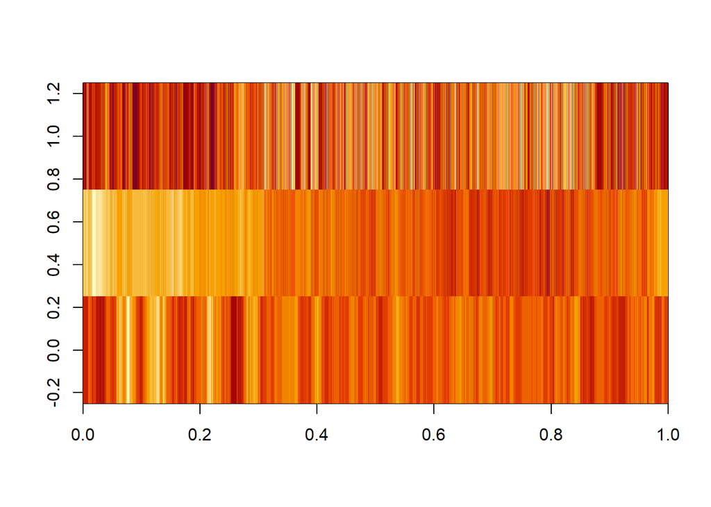

```r
training_res = (model %>% predict(c(list(training_all$inputs$train_call),
                                    training_all$inputs$train_cont,
                                    list(training_all$inputs$train_res)),verbose=F))
image(training_res)
```

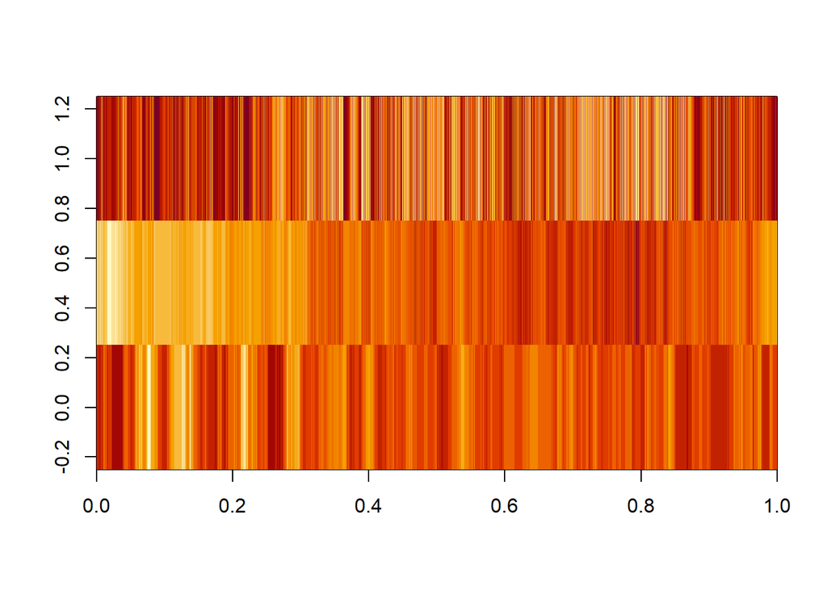

```r
image(training_all$outputs)
```

```r
print(paste0("Training RMSE: ",sqrt(mean((training_res-training_all$outputs)^2))))
```

```
## [1] "Training RMSE: 0.0255838208948307"
```

We can compare the results to the entire available data.

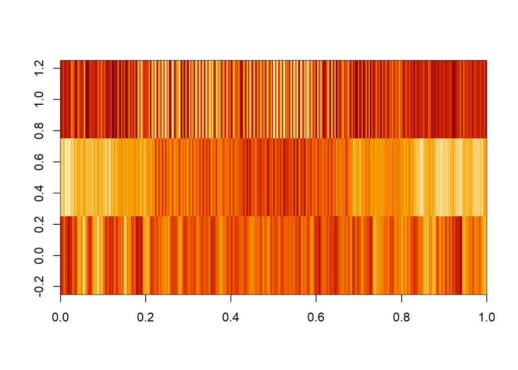

```r
all_res = (model %>% predict(c(list(prepared_data$formatted_all$inputs$x_call),
                               prepared_data$formatted_all$inputs$x_cont,
                               list(prepared_data$formatted_all$inputs$x_res)),verbose=F))
image(all_res)
```

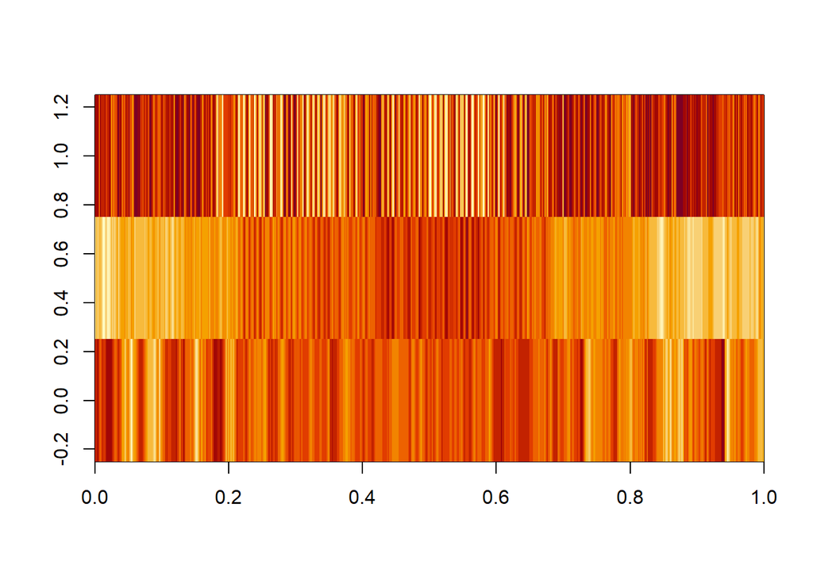

```r
image(prepared_data$formatted_all$outputs)
```

```r
print(paste0("All RMSE: ",sqrt(mean((all_res-prepared_data$formatted_all$outputs)^2))))
```

```
## [1] "All RMSE: 0.0429444437940706"
```

Now we have to evaluate it generatively, meaning we first give it a timestamp with no response, make it come up with a single prediction, pass that in as the response, and continue.

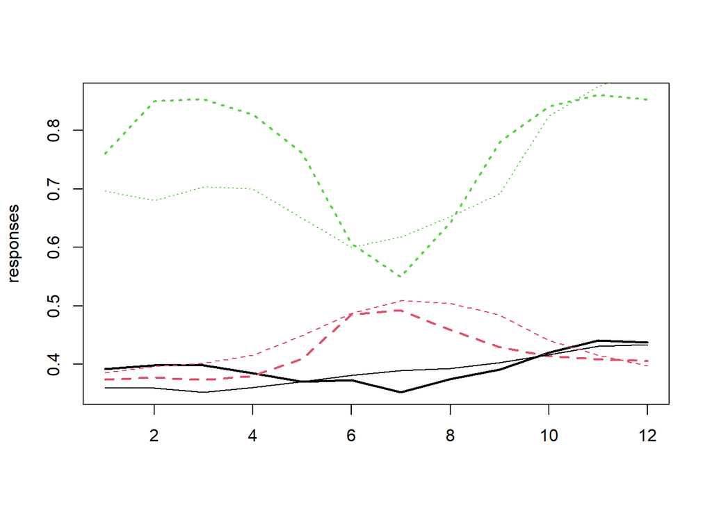

```r
#To use a random timestamp
#timestamp <- tail(prepared_data$resampled_time_series$res_resamp$timestamp,sample(12:50,1))[1]

#Selecting a timestamp
timestamp <- prepared_data$resampled_time_series$res_resamp$timestamp[4957]

responses = generate_prediction(model,timestamp,
                                prepared_data$resampled_time_series,
                                names(prepared_data$scaled_data),
                                config)

start_index = which(prepared_data$resampled_time_series$res_resamp$timestamp==timestamp)
end_index = start_index+config$res_size-1
res_features <- names(prepared_data$scaled_data)[config$res_feature_indx]
actual = prepared_data$resampled_time_series$res_resamp[start_index:end_index,res_features]

matplot(responses,type="l",lwd=2)
matpoints(actual,type="l")
```

This shows how our model compares to the resampled data with the thicker lines being our modeled response, but we can also use cerberusR’s descaling functionality to compare to the raw data.

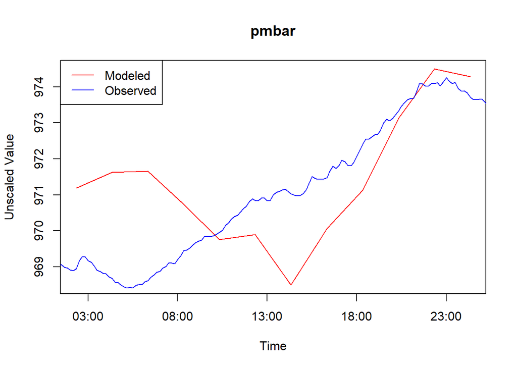

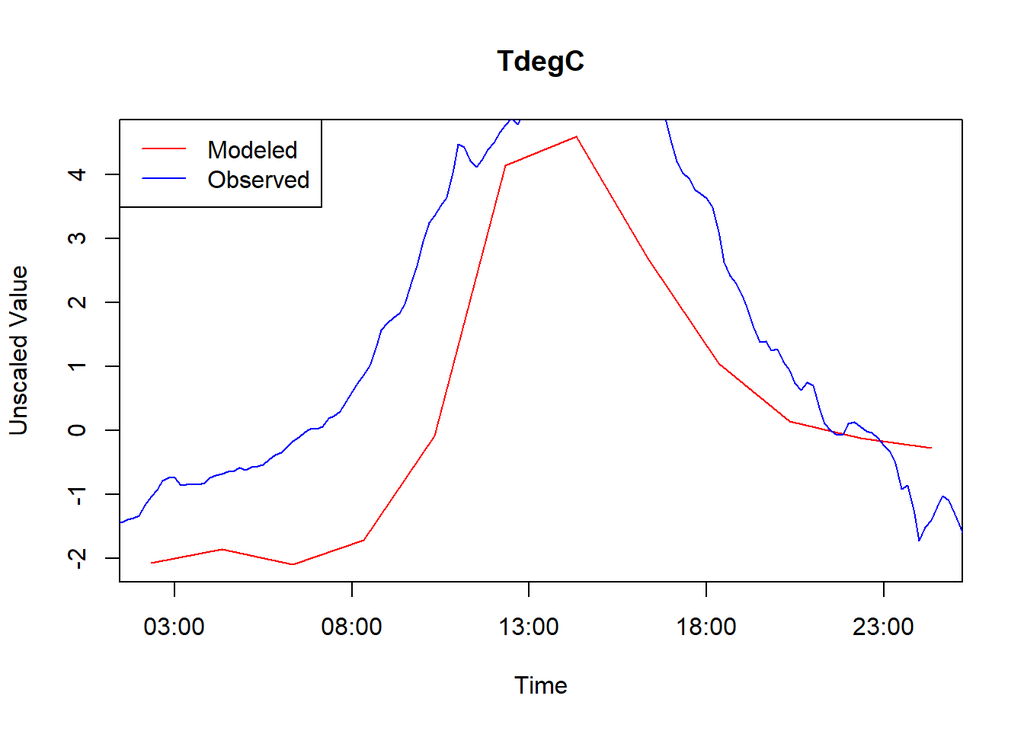

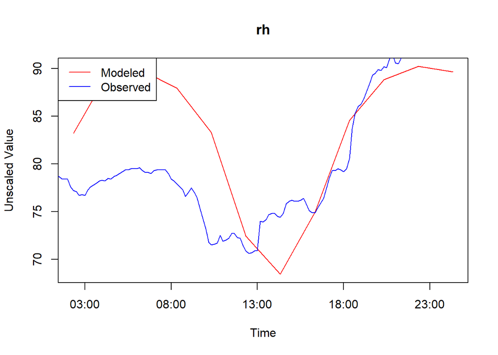

```r
generated_prediction <- descale_response(responses,
                                         prepared_data$min_max_df,
                                         config,
                                         names(prepared_data$scaled_data),
                                         timestamp)
for (ipp in 1:length(res_features)){
  matplot(generated_prediction[,1],generated_prediction[,res_features[ipp]],
          type="l",col="red",
          xlab = "Time",ylab="Unscaled Value")
  matlines(time_series_data[,1],time_series_data[,res_features[ipp]],col = "blue")
  title(res_features[ipp])
  legend('topleft', legend = c('Modeled', 'Observed'), col = c('red', 'blue'), lty = 1)
}
```